# R Notebook

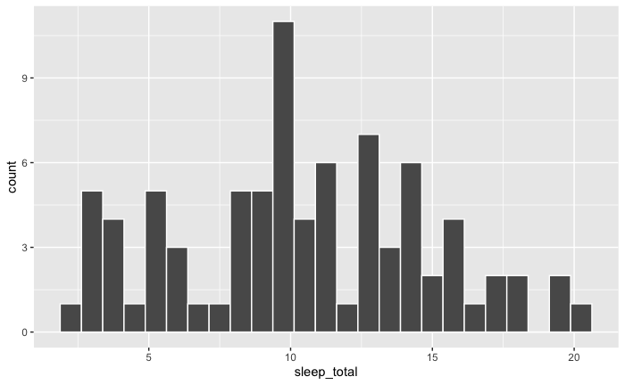

```r
msleep %>%
  ggplot(aes(x = sleep_total)) +
  geom_histogram(col = "white", bins = 25)
```

Jabberwockies sleep for around 7 hours a night, on average. Perform an appropriate statistical test to determine whether the mean sleep_total in the sampled population of animal types differs from the typical value for jabberwockies.

```r
msleep %>%
  summarise(mean(sleep_total))
```

| mean(sleep_total) |
| --- |
| 10.43373 |

```r
omni <- msleep %>%
  filter(vore == "omni")
omni
```

| name | genus | vore | order | conservation | sleep_total | sleep_rem | sleep_cycle | awake | brainwt | bodywt |
| --- | --- | --- | --- | --- | --- | --- | --- | --- | --- | --- |
| Owl monkey | Aotus | omni | Primates | NA | 17.0 | 1.8 | NA | 7.0 | 0.01550 | 0.480 |
| Greater short-tailed shrew | Blarina | omni | Soricomorpha | lc | 14.9 | 2.3 | 0.1333333 | 9.1 | 0.00029 | 0.019 |
| Grivet | Cercopithecus | omni | Primates | lc | 10.0 | 0.7 | NA | 14.0 | NA | 4.750 |
| Star-nosed mole | Condylura | omni | Soricomorpha | lc | 10.3 | 2.2 | NA | 13.7 | 0.00100 | 0.060 |
| African giant pouched rat | Cricetomys | omni | Rodentia | NA | 8.3 | 2.0 | NA | 15.7 | 0.00660 | 1.000 |
| Lesser short-tailed shrew | Cryptotis | omni | Soricomorpha | lc | 9.1 | 1.4 | 0.1500000 | 14.9 | 0.00014 | 0.005 |
| North American Opossum | Didelphis | omni | Didelphimorphia | lc | 18.0 | 4.9 | 0.3333333 | 6.0 | 0.00630 | 1.700 |
| European hedgehog | Erinaceus | omni | Erinaceomorpha | lc | 10.1 | 3.5 | 0.2833333 | 13.9 | 0.00350 | 0.770 |
| Patas monkey | Erythrocebus | omni | Primates | lc | 10.9 | 1.1 | NA | 13.1 | 0.11500 | 10.000 |
| Galago | Galago | omni | Primates | NA | 9.8 | 1.1 | 0.5500000 | 14.2 | 0.00500 | 0.200 |

[output cut: 10 more lines]

```r
herbi <- msleep %>%
  filter(vore == "herbi")
herbi
```

| name | genus | vore | order | conservation | sleep_total | sleep_rem | sleep_cycle | awake | brainwt | bodywt |
| --- | --- | --- | --- | --- | --- | --- | --- | --- | --- | --- |
| Mountain beaver | Aplodontia | herbi | Rodentia | nt | 14.4 | 2.4 | NA | 9.6 | NA | 1.350 |
| Cow | Bos | herbi | Artiodactyla | domesticated | 4.0 | 0.7 | 0.6666667 | 20.0 | 0.42300 | 600.000 |
| Three-toed sloth | Bradypus | herbi | Pilosa | NA | 14.4 | 2.2 | 0.7666667 | 9.6 | NA | 3.850 |
| Roe deer | Capreolus | herbi | Artiodactyla | lc | 3.0 | NA | NA | 21.0 | 0.09820 | 14.800 |
| Goat | Capri | herbi | Artiodactyla | lc | 5.3 | 0.6 | NA | 18.7 | 0.11500 | 33.500 |
| Guinea pig | Cavis | herbi | Rodentia | domesticated | 9.4 | 0.8 | 0.2166667 | 14.6 | 0.00550 | 0.728 |
| Chinchilla | Chinchilla | herbi | Rodentia | domesticated | 12.5 | 1.5 | 0.1166667 | 11.5 | 0.00640 | 0.420 |
| Tree hyrax | Dendrohyrax | herbi | Hyracoidea | lc | 5.3 | 0.5 | NA | 18.7 | 0.01230 | 2.950 |
| Asian elephant | Elephas | herbi | Proboscidea | en | 3.9 | NA | NA | 20.1 | 4.60300 | 2547.000 |
| Horse | Equus | herbi | Perissodactyla | domesticated | 2.9 | 0.6 | 1.0000000 | 21.1 | 0.65500 | 521.000 |

[output cut: 22 more lines]

```r
mean(herbi$sleep_total)
```

```
[1] 9.509375
```

```r
mean(omni$sleep_total)
```

```
[1] 10.925
```

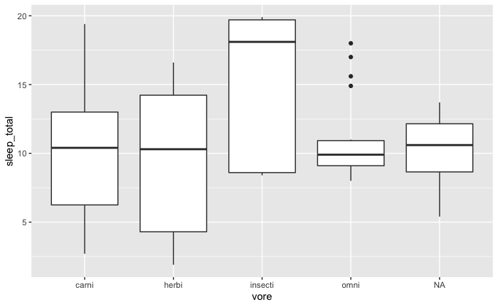

```r
msleep %>%
  ggplot(aes(x = vore, y = sleep_total)) +
  geom_boxplot()
```

Perform an appropriate statistical test to determine whether the proportion of domesticated animal types in the population of animal types is greater than 5%. [Hint - think about creating an is_domesticated variable for the analysis]

```r
domesticated <- msleep %>%
  filter(conservation == "domesticated") %>%
  mutate(is_domesticated = "domesticated")
domesticated
```

| name | genus | vore | order | conservation | sleep_total | sleep_rem | sleep_cycle | awake | brainwt | bodywt | is_domesticated |
| --- | --- | --- | --- | --- | --- | --- | --- | --- | --- | --- | --- |
| Cow | Bos | herbi | Artiodactyla | domesticated | 4.0 | 0.7 | 0.6666667 | 20.0 | 0.4230 | 600.000 | domesticated |
| Dog | Canis | carni | Carnivora | domesticated | 10.1 | 2.9 | 0.3333333 | 13.9 | 0.0700 | 14.000 | domesticated |
| Guinea pig | Cavis | herbi | Rodentia | domesticated | 9.4 | 0.8 | 0.2166667 | 14.6 | 0.0055 | 0.728 | domesticated |
| Chinchilla | Chinchilla | herbi | Rodentia | domesticated | 12.5 | 1.5 | 0.1166667 | 11.5 | 0.0064 | 0.420 | domesticated |
| Horse | Equus | herbi | Perissodactyla | domesticated | 2.9 | 0.6 | 1.0000000 | 21.1 | 0.6550 | 521.000 | domesticated |
| Donkey | Equus | herbi | Perissodactyla | domesticated | 3.1 | 0.4 | NA | 20.9 | 0.4190 | 187.000 | domesticated |
| Domestic cat | Felis | carni | Carnivora | domesticated | 12.5 | 3.2 | 0.4166667 | 11.5 | 0.0256 | 3.300 | domesticated |
| Rabbit | Oryctolagus | herbi | Lagomorpha | domesticated | 8.4 | 0.9 | 0.4166667 | 15.6 | 0.0121 | 2.500 | domesticated |
| Sheep | Ovis | herbi | Artiodactyla | domesticated | 3.8 | 0.6 | NA | 20.2 | 0.1750 | 55.500 | domesticated |
| Pig | Sus | omni | Artiodactyla | domesticated | 9.1 | 2.4 | 0.5000000 | 14.9 | 0.1800 | 86.250 | domesticated |

```r
msleep %>%
  mutate(is_domesticated = ifelse(conservation == "domesticated", "TRUE", "FALSE")) %>%
  group_by(is_domesticated) %>%
  summarise(n = n())
```

| is_domesticated | n |
| --- | --- |
| FALSE | 44 |
| TRUE | 10 |
| NA | 29 |

specify() #specify the the variables of interest hypothesize() # state the null hypothesis  
generate() # what method will use to generate null hypotheses  
calculate() #statistic of interest

Coffee shop problem. Significance level: 0.05, calculated p-value: 0.07

Website company problem. Significance level: 0.01, p-value: 0.006

Manufacturing company problem. Significance level: 0.05, p-value: 0.55